# Reviewers comment v1

Hello Felimon!

I'm happy to review your project today 🙌

My name is **Gerardo Flores** and you can find me on the HUB as https://hub.tripleten.com/u/1949959f

You can find my comments under the heading **«Review»**. I will categorize my comments in green, blue or red boxes like this:

**Success:** if everything is done successfully

**Remarks:** if I can give some recommendations or ways to improve the project

**Needs fixing:** if the block requires some corrections. Work cant be accepted with the red comments

Please don't remove my comments :) If you have any questions don't hesitate to respond to my comments in a different section.

**Student comments:** For example like this

**Reviewer's comment v1:**

**Overall Feedback**

Hello Felimon,

You’ve submitted another project—great work! Your commitment to pushing through the challenges of this program is admirable.

After reviewing your submission, it is approved.

You can find my more detailed notes within your project notebook in the `Reviewer's comment v1:` section.

If you find yourself uncertain or in need of further insights, never hesitate to consult with your tutor or ask your questions here. We are here to guide and assist you.

# Video Game Sales Analysis Project

## Project Overview

In this project, you'll analyze video game sales data to identify patterns that determine a game's success. Working as an analyst for the online store Ice, you'll use this information to help plan future advertising campaigns.

## Environment Setup and Required Libraries

**Reviewer's comment v1**

Great job keeping the additional information about the project goal! Additionally, you could add a short description of the tasks you plan to perform and the available data. This information could be helpful for the notebook reader.

```python
# Import all required libraries
import pandas as pd
import numpy as np
import matplotlib.pyplot as plt
from scipy import stats

# Set display options for better readability
pd.set_option('display.max_columns',
             None)
pd.set_option('display.max_rows', 100)
pd.set_option('display.float_format',
             '{:.2f}'.format)

# Set plotting style
plt.style.use('ggplot')

print("Import Success")
print(f"Pandas version: {pd.__version__}")
print(f"Numpy version: {np.__version__}")
print(f"Matplotlib version: {plt.matplotlib.__version__}")
```

```
Import Success
Pandas version: 1.2.4
Numpy version: 1.21.2
Matplotlib version: 3.3.4
```

## Step 1: Loading and Initial Data Exploration

First, let's load our dataset and examine its basic properties:

```python
# Load the dataset
df = pd.read_csv('/datasets/games.csv')
```

```python
# Display basic information about the dataset
print(f"Toltal number of records: {len(df)}")
print(f"Total number of columns: {len(df.columns)}")
print(df.head(10))
print(df.info())
print(df.describe(include='all'))
```

```
Toltal number of records: 16715
Total number of columns: 11
                        Name Platform  Year_of_Release         Genre  \
0                 Wii Sports      Wii          2006.00        Sports
1          Super Mario Bros.      NES          1985.00      Platform
2             Mario Kart Wii      Wii          2008.00        Racing
3          Wii Sports Resort      Wii          2009.00        Sports
4   Pokemon Red/Pokemon Blue       GB          1996.00  Role-Playing
5                     Tetris       GB          1989.00        Puzzle
6      New Super Mario Bros.       DS          2006.00      Platform
7                   Wii Play      Wii          2006.00          Misc
8  New Super Mario Bros. Wii      Wii          2009.00      Platform
9                  Duck Hunt      NES          1984.00       Shooter

   NA_sales  EU_sales  JP_sales  Other_sales  Critic_Score User_Score Rating
0     41.36     28.96      3.77         8.45         76.00          8      E
1     29.08      3.58      6.81         0.77           NaN        NaN    NaN
2     15.68     12.76      3.79         3.29         82.00        8.3      E
3     15.61     10.93      3.28         2.95         80.00          8      E
4     11.27      8.89     10.22         1.00           NaN        NaN    NaN
5     23.20      2.26      4.22         0.58           NaN        NaN    NaN
6     11.28      9.14      6.50         2.88         89.00        8.5      E
7     13.96      9.18      2.93         2.84         58.00        6.6      E
8     14.44      6.94      4.70         2.24         87.00        8.4      E
9     26.93      0.63      0.28         0.47           NaN        NaN    NaN
<class 'pandas.core.frame.DataFrame'>
RangeIndex: 16715 entries, 0 to 16714
Data columns (total 11 columns):
 #   Column           Non-Null Count  Dtype
---  ------           --------------  -----
 0   Name             16713 non-null  object
 1   Platform         16715 non-null  object
 2   Year_of_Release  16446 non-null  float64
 3   Genre            16713 non-null  object
 4   NA_sales         16715 non-null  float64
 5   EU_sales         16715 non-null  float64
 6   JP_sales         16715 non-null  float64
 7   Other_sales      16715 non-null  float64
 8   Critic_Score     8137 non-null   float64
 9   User_Score       10014 non-null  object
```

[output cut: 27 more lines]

```
75%         0.24      0.11      0.04         0.03         79.00        NaN
max        41.36     28.96     10.22        10.57         98.00        NaN

       Rating
count    9949
unique      8
top         E
freq     3990
mean      NaN
std       NaN
min       NaN
25%       NaN
50%       NaN
75%       NaN
max       NaN
```

```python
# Check for duplicate entries
duplicates = df.duplicated().sum()
print(f"Number of duplicate rows: {duplicates}")


# Immediate patterns and anomalies
negative_sales = ((df['NA_sales'] < 0) | (df['EU_sales'] < 0) |
                  (df['JP_sales'] < 0) | (df['Other_sales'] < 0)).sum()
print(f"Games with negative sales: {negative_sales}")
print(f"Critic_Score range: {df['Critic_Score'].min()} to {df['Critic_Score'].max()}")
```

```
Number of duplicate rows: 0
Games with negative sales: 0
Critic_Score range: 13.0 to 98.0
```

# Key Observations

Total Number of records in our dataset: 16,715

Data Types Present in each Column: Name:object, Platform:object, Year_of_Release:float64, Genre:object, NA_sales:float64, EU_sales:float64, JP_sales:float64, Other_sales:float64, Critic_Score:float64,User_Score:object, Rating:object

Issues with the data: Column names need to be standardized to lowercase for consistent referencing. user_score values equal to "tbd" need to be converted to NaN and excluded from rating analysis. year_of_release, genre, critic_score, user_score, and rating need to be handled by using only valid rows during later comparisons.

Patterns or Anomalies: Missing portions of datasets like in user_score and rating.

### Key Questions to Answer:

- What's the total number of records in our dataset?
- What data types are present in each column?
- Are there any obvious issues with the data?
- Do we see any immediate patterns or anomalies?

**Reviewer's comment v1**

Well done!

## Step 2: Data Preparation

### 2.1 Standardizing Column Names

```python
# Make a Working Copy
# Convert column names to lowercase
df = df.copy()
print("Before: ", df.columns.tolist())

df.columns = df.columns.str.lower()
```

```
Before:  ['Name', 'Platform', 'Year_of_Release', 'Genre', 'NA_sales', 'EU_sales', 'JP_sales', 'Other_sales', 'Critic_Score', 'User_Score', 'Rating']
```

```python
# Verify the changes
print("After: ", df.columns.tolist())
```

```
After:  ['name', 'platform', 'year_of_release', 'genre', 'na_sales', 'eu_sales', 'jp_sales', 'other_sales', 'critic_score', 'user_score', 'rating']
```

### 2.2 Data Type Conversion

```python
# Check current data types
print("Current data types:")
print(df.dtypes)
```

```
Current data types:
name                object
platform            object
year_of_release    float64
genre               object
na_sales           float64
eu_sales           float64
jp_sales           float64
other_sales        float64
critic_score       float64
user_score          object
rating              object
dtype: object
```

```python
# Make changes to data types if necessary
# Describe the columns where the data types have been changed and why.
print(f"user_score 'tbd' count before conversion: \n{(df['user_score'] == 'tbd').sum()}")
df['user_score'] = pd.to_numeric(df['user_score'], errors='coerce')
```

```
user_score 'tbd' count before conversion:
2424
```

```python
# Pay attention to the abbreviation TBD (to be determined). Specify how you intend to handle such cases.
print(f"user_score 'tbd' converted to Nan")
print(f"user_score 'tbd' count after conversion: \n{(df['user_score'] == 'tbd').sum()}")

print(f"\nKeeping year_of_release as float64 since pandas handles Nan values in floats")
```

```
user_score 'tbd' converted to Nan
user_score 'tbd' count after conversion:
0

Keeping year_of_release as float64 since pandas handles Nan values in floats
```

### 2.3 Handling Missing Values

```python
# Examine missing values
# Calculate percentage of missing values
missing_summary = pd.DataFrame({'Column': df.columns, 'Missing_Count':
                                df.isnull().sum().values,
                               'Missing_Percentatge': (df.isnull().sum().values /
                                                      len(df) * 100).round(2)})
print(missing_summary[missing_summary['Missing_Count'] > 0])
```

```
             Column  Missing_Count  Missing_Percentatge
0              name              2                 0.01
2   year_of_release            269                 1.61
3             genre              2                 0.01
8      critic_score           8578                51.32
9        user_score           9125                54.59
10           rating           6766                40.48
```

# Analyze patterns in missing values

# Handle missing values according to your strategy

# Explain why you filled, left untouched, or left missing values blank

Keep year_of_release as float 64 since pandas handles NaN values in floats

**Reviewer's comment v1**

Great strategy!

### 2.4 Calculate Total Sales

```python
# Calculate total sales across all regions and put them in a different column
df['total_sales'] = (df['na_sales'] +
                    df['eu_sales'] +
                    df['jp_sales'] +
                    df['other_sales'])
print("Sample of total_sales column:")
print(df[['name', 'na_sales', 'eu_sales', 'jp_sales', 'other_sales', 'total_sales']].head(10))
print("\n")
print("Final total sales data set")
print(f"Shape: {df.shape}")
print(f"Data types:\ndf.dtypes")
print(f"Missing values summary:")
print(df.isnull().sum())
print(df['total_sales'].describe())
```

```
Sample of total_sales column:
                        name  na_sales  eu_sales  jp_sales  other_sales  \
0                 Wii Sports     41.36     28.96      3.77         8.45
1          Super Mario Bros.     29.08      3.58      6.81         0.77
2             Mario Kart Wii     15.68     12.76      3.79         3.29
3          Wii Sports Resort     15.61     10.93      3.28         2.95
4   Pokemon Red/Pokemon Blue     11.27      8.89     10.22         1.00
5                     Tetris     23.20      2.26      4.22         0.58
6      New Super Mario Bros.     11.28      9.14      6.50         2.88
7                   Wii Play     13.96      9.18      2.93         2.84
8  New Super Mario Bros. Wii     14.44      6.94      4.70         2.24
9                  Duck Hunt     26.93      0.63      0.28         0.47

   total_sales
0        82.54
1        40.24
2        35.52
3        32.77
4        31.38
5        30.26
6        29.80
7        28.91
8        28.32
9        28.31


Final total sales data set
Shape: (16715, 12)
Data types:
df.dtypes
Missing values summary:
name                  2
platform              0
year_of_release     269
genre                 2
na_sales              0
eu_sales              0
jp_sales              0
other_sales           0
critic_score       8578
user_score         9125
rating             6766
total_sales           0
dtype: int64
count   16715.00
mean        0.53
std         1.55
min         0.00
25%         0.06
50%         0.17
75%         0.47
max        82.54
Name: total_sales, dtype: float64
```

**Reviewer's comment v1**

Well done!

# Step 3: Analyzing Video Game Sales Data

## 3.1 Temporal Analysis of Game Releases

Let's first examine the distribution of game releases across different years to understand our data's coverage and significance:

```python
# Create a DataFrame with game releases by year
games_by_year = df['year_of_release'].value_counts().sort_index()
```

```python
# Visualize the distribution of games across years
print("Games released by year:")
print(games_by_year)
```

```
Games released by year:
1980.00       9
1981.00      46
1982.00      36
1983.00      17
1984.00      14
1985.00      14
1986.00      21
1987.00      16
1988.00      15
1989.00      17
1990.00      16
1991.00      41
1992.00      43
1993.00      62
1994.00     121
1995.00     219
1996.00     263
1997.00     289
1998.00     379
1999.00     338
2000.00     350
2001.00     482
2002.00     829
2003.00     775
2004.00     762
2005.00     939
2006.00    1006
2007.00    1197
2008.00    1427
2009.00    1426
2010.00    1255
2011.00    1136
2012.00     653
2013.00     544
2014.00     581
2015.00     606
2016.00     502
Name: year_of_release, dtype: int64
```

```python
# Display summary statistics for each year
# Year with most games
max_year_idx = games_by_year.idxmax()
max_year = int(max_year_idx)
max_games = games_by_year[max_year_idx]

# Year with fewest games
min_year_idx = games_by_year.idxmin()
min_year = int(min_year_idx)
min_games = games_by_year[min_year_idx]

# Calculate statistics
total_years = len(games_by_year)
mean_games = games_by_year.mean()
median_games = games_by_year.median()
std_games = games_by_year.std()

print(f"Year with most games: {max_year} ({max_games} games)")
print(f"Year with fewest games: {min_year} ({min_games} games)")
print(f"Average games per year: {mean_games:.1f}")
print(f"Median games per year: {median_games:.1f}")
print(f"Standard Deviation: {std_games:.1f}")
print("\n")

# Recent years
recent_years = games_by_year[games_by_year.index >= 2010]
for year, count in recent_years.items():
    print(f"{int(year)}: {count:>4} games")

# Observations
print("\nPeak years of game releases: 2008-2011 (1200-1400 games per year)")
print("Decline after 2011")
print("2013-2015: Stable release rate (544-606 games per year)")
print("2016: Incomplete data (502 games, partial year)")
print('\n')
print("Use 2010-2016 for 2017 forecasts")
```

```
Year with most games: 2008 (1427 games)
Year with fewest games: 1980 (9 games)
Average games per year: 444.5
Median games per year: 338.0
Standard Deviation: 451.6


2010: 1255 games
2011: 1136 games
2012:  653 games
2013:  544 games
2014:  581 games
2015:  606 games
2016:  502 games

Peak years of game releases: 2008-2011 (1200-1400 games per year)
Decline after 2011
2013-2015: Stable release rate (544-606 games per year)
2016: Incomplete data (502 games, partial year)


Use 2010-2016 for 2017 forecasts
```

# Key Observations

Peak years of game releases: 2008-2011 (1200-1400 games per year) Decline after 2011 2013-2015: Stable release rate (544-606 games per year) 2016: Incomplete data (502 games, partial year)

Use 2010-2016 for 2017 forecasts

### Questions to Consider:

- Which years show significant numbers of game releases?
- Are there any notable trends or patterns in the number of releases?
- Is there enough recent data to make predictions for 2017?

**Reviewer's comment v1**

Well done!

## 3.2 Platform Sales Analysis Over Time

Now let's analyze how sales vary across platforms and years:

```python
# Calculate total sales by platform and year
platform_year_sales = (df.groupby(['platform', 'year_of_release'], as_index=False)['total_sales'].sum().sort_values(['platform', 'year_of_release']))
print(platform_year_sales.head(20))
```

```
   platform  year_of_release  total_sales
0      2600          1980.00        11.38
1      2600          1981.00        35.68
2      2600          1982.00        28.88
3      2600          1983.00         5.84
4      2600          1984.00         0.27
5      2600          1985.00         0.45
6      2600          1986.00         0.67
7      2600          1987.00         1.94
8      2600          1988.00         0.74
9      2600          1989.00         0.63
10      3DO          1994.00         0.02
11      3DO          1995.00         0.08
12      3DS          2011.00        63.20
13      3DS          2012.00        51.36
14      3DS          2013.00        56.57
15      3DS          2014.00        43.76
16      3DS          2015.00        27.78
17      3DS          2016.00        15.14
18       DC          1998.00         3.38
19       DC          1999.00         5.16
```

```
year_of_release  1980.00  1981.00  1982.00  1983.00  1984.00  1985.00  \
platform
2600               11.38    35.68    28.88     5.84     0.27     0.45
3DO                 0.00     0.00     0.00     0.00     0.00     0.00
3DS                 0.00     0.00     0.00     0.00     0.00     0.00
DC                  0.00     0.00     0.00     0.00     0.00     0.00
DS                  0.00     0.00     0.00     0.00     0.00     0.02

year_of_release  1986.00  1987.00  1988.00  1989.00  1990.00  1991.00  \
platform
2600                0.67     1.94     0.74     0.63     0.00     0.00
3DO                 0.00     0.00     0.00     0.00     0.00     0.00
3DS                 0.00     0.00     0.00     0.00     0.00     0.00
DC                  0.00     0.00     0.00     0.00     0.00     0.00
DS                  0.00     0.00     0.00     0.00     0.00     0.00

year_of_release  1992.00  1993.00  1994.00  1995.00  1996.00  1997.00  \
platform
2600                0.00     0.00     0.00     0.00     0.00     0.00
3DO                 0.00     0.00     0.02     0.08     0.00     0.00
3DS                 0.00     0.00     0.00     0.00     0.00     0.00
DC                  0.00     0.00     0.00     0.00     0.00     0.00
DS                  0.00     0.00     0.00     0.00     0.00     0.00

year_of_release  1998.00  1999.00  2000.00  2001.00  2002.00  2003.00  \
platform
2600                0.00     0.00     0.00     0.00     0.00     0.00
3DO                 0.00     0.00     0.00     0.00     0.00     0.00
3DS                 0.00     0.00     0.00     0.00     0.00     0.00
DC                  3.38     5.16     5.99     1.07     0.29     0.00
DS                  0.00     0.00     0.00     0.00     0.00     0.00

year_of_release  2004.00  2005.00  2006.00  2007.00  2008.00  2009.00  \
platform
2600                0.00     0.00     0.00     0.00     0.00     0.00
3DO                 0.00     0.00     0.00     0.00     0.00     0.00
3DS                 0.00     0.00     0.00     0.00     0.00     0.00
DC                  0.00     0.00     0.00     0.02     0.04     0.00
DS                 17.27   130.14   119.81   146.94   145.31   119.54

year_of_release  2010.00  2011.00  2012.00  2013.00  2014.00  2015.00  2016.00
platform
2600                0.00     0.00     0.00     0.00     0.00     0.00     0.00
3DO                 0.00     0.00     0.00     0.00     0.00     0.00     0.00
3DS                 0.00    63.20    51.36    56.57    43.76    27.78    15.14
DC                  0.00     0.00     0.00     0.00     0.00     0.00     0.00
DS                 85.02    26.18    11.01     1.54     0.00     0.00     0.00
```

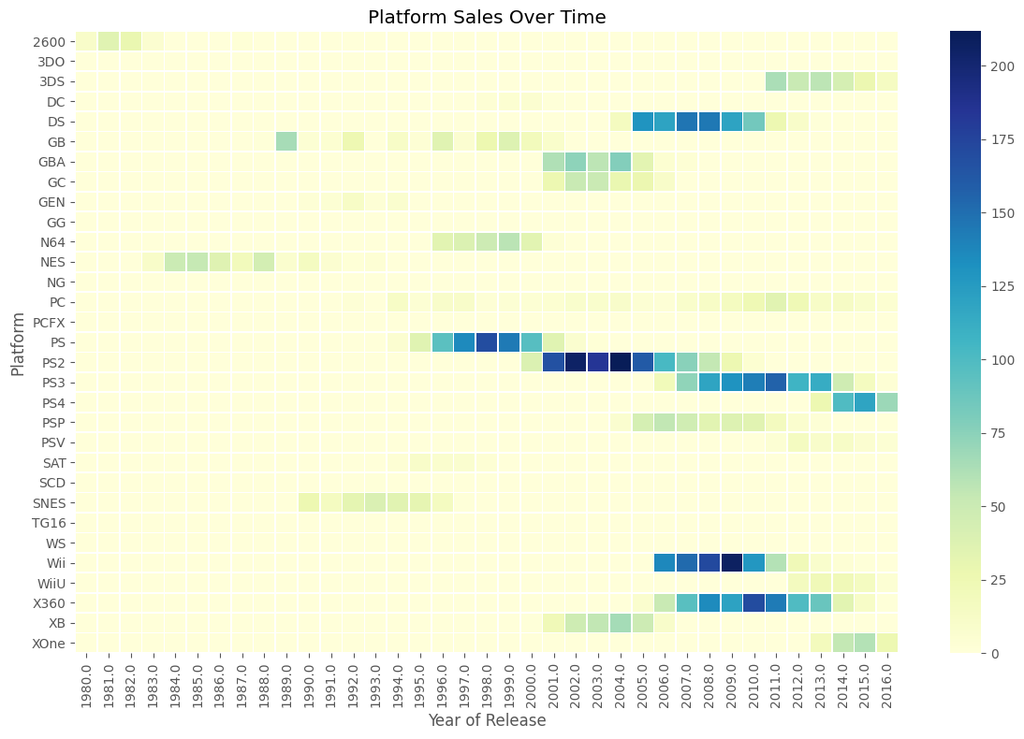

```python
# Create a heatmap of platform sales over time
platform_year_matrix = (platform_year_sales.pivot_table(index='platform', columns='year_of_release',
                                                        values='total_sales', fill_value=0))
print(platform_year_matrix.head())
import seaborn as sns
plt.figure(figsize=(12, 8))
sns.heatmap(platform_year_matrix, cmap='YlGnBu', linewidths=0.5)
plt.title('Platform Sales Over Time')
plt.xlabel('Year of Release')
plt.ylabel('Platform')
plt.tight_layout()
plt.show()
```

```python
# Identify platforms with declining sales
platform_year_sorted = (platform_year_sales.sort_values(['platform', 'year_of_release']).reset_index(drop=True))

declining_platforms = []
for platform, group in platform_year_sorted.groupby('platform'):
    first_year_sales = group.iloc[0]['total_sales']
    last_year_sales = group.iloc[-1]['total_sales']

    if last_year_sales < first_year_sales:
        declining_platforms.append({
            'platform': platform,
            'first_year': int(group.iloc[0]['year_of_release']),
            'first_sales': first_year_sales,
            'last_year': int(group.iloc[-1]['year_of_release']),
            'last_sales': last_year_sales})
declining_df = pd.DataFrame(declining_platforms).sort_values('first_sales', ascending=False)

print("Platforms with declining sales from first to last year:")
print(declining_df.head(20))
```

```
Platforms with declining sales from first to last year:
   platform  first_year  first_sales  last_year  last_sales
16      Wii        2006       137.15       2016        0.18
1       3DS        2011        63.20       2016       15.14
8       PS2        2000        39.17       2011        0.45
4       N64        1996        34.10       2002        0.08
3        GC        2001        26.34       2007        0.27
14     SNES        1990        26.15       1999        0.26
9       PS3        2006        20.96       2016        3.60
17     WiiU        2012        17.56       2016        4.60
0      2600        1980        11.38       1989        0.63
5       NES        1983        10.96       1994        0.11
18     X360        2005         8.25       2016        1.52
10      PSP        2004         7.06       2015        0.12
7        PS        1994         6.03       2003        2.07
11      PSV        2011         4.63       2016        4.25
12      SAT        1994         3.65       1999        0.09
2        DC        1998         3.38       2008        0.04
13      SCD        1993         1.50       1994        0.36
19       XB        2000         0.99       2008        0.18
15       WS        1999         0.46       2001        0.28
6        NG        1993         0.21       1996        0.10
```

# Key Observations

Consistent Sales over time regarding Platform: PS2, PS3, and X360

Typical lifecyle of a gaming platform: Most platforms do not live past 10 years in the market. Marginal platforms survive much less, around 5 or 6 years. Most marginal platforms have long exceeded their lifecycle, which is why there presence in the market is negligible.

### Questions to Consider:

- Which platforms show consistent sales over time?
- Can you identify platforms that have disappeared from the market?
- What's the typical lifecycle of a gaming platform?

**Reviewer's comment v1**

That-s correct!

## 3.3 Determining Relevant Time Period

Based on your analysis above, determine the appropriate time period for predicting 2017 sales:

```python
# Your code here to filter the dataset to relevant years
# Example:
# relevant_years = [XXXX, XXXX, XXXX] # Replace with your chosen years
# df_relevant = df[df['year_of_release'].isin(relevant_years)]
relevant_years = list(range(2010, 2017)) # includes 2010 but excludes 2017
df_relevant = df[df['year_of_release'].isin(relevant_years)].copy()

total_rows = len(df)
relevant_rows = len(df_relevant)

print("Relevant years:", relevant_years)
print("Rows in full dataset:", total_rows)
print("Rows in relevant period:", relevant_rows)

# Justify your choice with data

print("\nOlder years (1980s–1990s) mainly contain platforms that no longer exist, making them less useful for predicting 2017 sales.")
print("From about 2010 onward, some of the main modern platforms (PS3, PS4, X360, XOne, Wii, WiiU, etc.)\nare active and yearly sales volumes are high.")
print("Using 2010–2016 keeps the data recent, reflects the current console generation, and \nstill preserves enough observations for reliable analysis.")
```

```
Relevant years: [2010, 2011, 2012, 2013, 2014, 2015, 2016]
Rows in full dataset: 16715
Rows in relevant period: 5277

Older years (1980s–1990s) mainly contain platforms that no longer exist, making them less useful for predicting 2017 sales.
From about 2010 onward, some of the main modern platforms (PS3, PS4, X360, XOne, Wii, WiiU, etc.)
are active and yearly sales volumes are high.
Using 2010–2016 keeps the data recent, reflects the current console generation, and
still preserves enough observations for reliable analysis.
```

# Key Decisions

Older years (1980s–1990s) mainly contain platforms that no longer exist, making them less useful for predicting 2017 sales.

From about 2010 onward, some of the main modern platforms (PS3, PS4, X360, XOne, Wii, WiiU, etc.) are active and yearly sales volumes are high.

Using 2010–2016 keeps the data recent, reflects the current console generation, and \nstill preserves enough observations for reliable analysis.

### Document Your Decision:

- What years did you select and why?
- How does this period reflect current market conditions?
- What factors influenced your decision?

**Reviewer's comment v1**

Well done!

## 3.4 Platform Performance Analysis

Using your selected time period, let's analyze platform performance:

```python
# Analyze platform sales trends
# Sort platforms by total sales
platform_sales = (df_relevant.groupby('platform')['total_sales'].sum().sort_values(ascending=False))
print("Total sales by platform (selected period):")
print(platform_sales.head(20))
```

```
Total sales by platform (selected period):
platform
PS3    587.74
X360   550.41
PS4    314.14
3DS    257.81
Wii    222.97
XOne   159.32
DS     123.75
PC     121.96
WiiU    82.19
PSP     64.05
PSV     53.81
PS2      6.09
Name: total_sales, dtype: float64
```

[figure not shown]

```
Year-over-year growth (%) for top platforms:
   platform  year_of_release  total_sales  growth_pct
0       PS3          2006.00        20.96         NaN
1       PS3          2007.00        73.19      249.19
2       PS3          2008.00       118.52       61.93
3       PS3          2009.00       130.93       10.47
4       PS3          2010.00       142.17        8.58
5       PS3          2011.00       156.78       10.28
6       PS3          2012.00       107.36      -31.52
7       PS3          2013.00       113.25        5.49
8       PS3          2014.00        47.76      -57.83
9       PS3          2015.00        16.82      -64.78
10      PS3          2016.00         3.60      -78.60
11     X360          2005.00         8.25         NaN
12     X360          2006.00        51.62      525.70
13     X360          2007.00        95.41       84.83
14     X360          2008.00       135.26       41.77
15     X360          2009.00       120.29      -11.07
16     X360          2010.00       170.03       41.35
17     X360          2011.00       143.84      -15.40
18     X360          2012.00        99.74      -30.66
19     X360          2013.00        88.58      -11.19
```

```python
# Visualize top platforms
# Calculate year-over-year growth for each platform
# Your code here to calculate and visualize platform growth rates

top_n = 6
top_platforms = platform_sales.head(top_n).index
top_trends = platform_year_sales[platform_year_sales['platform'].isin(top_platforms)]

plt.figure(figsize=(10, 6))
for p in top_platforms:
    subset = top_trends[top_trends['platform'] == p]
    plt.plot(subset['year_of_release'],
             subset['total_sales'],
             marker='o',
             label=p)
plt.title("Year-over-Year Sales for Top Platforms (Selected Period)")
plt.xlabel("Year of Release")
plt.ylabel("Total Sales (million units)")
plt.legend()
plt.tight_layout()
plt.show()

growth_list = []
for p in top_platforms:
    subset = (top_trends[top_trends['platform'] == p]
        .sort_values('year_of_release'))
    # percentage change year to year
    subset['growth_pct'] = subset['total_sales'].pct_change() * 100
    growth_list.append(subset)

growth_df = pd.concat(growth_list, ignore_index=True)
print("Year-over-year growth (%) for top platforms:")
print(growth_df.head(20))
```

## 3.5 Sales Distribution Analysis

Let's examine the distribution of sales across platforms:

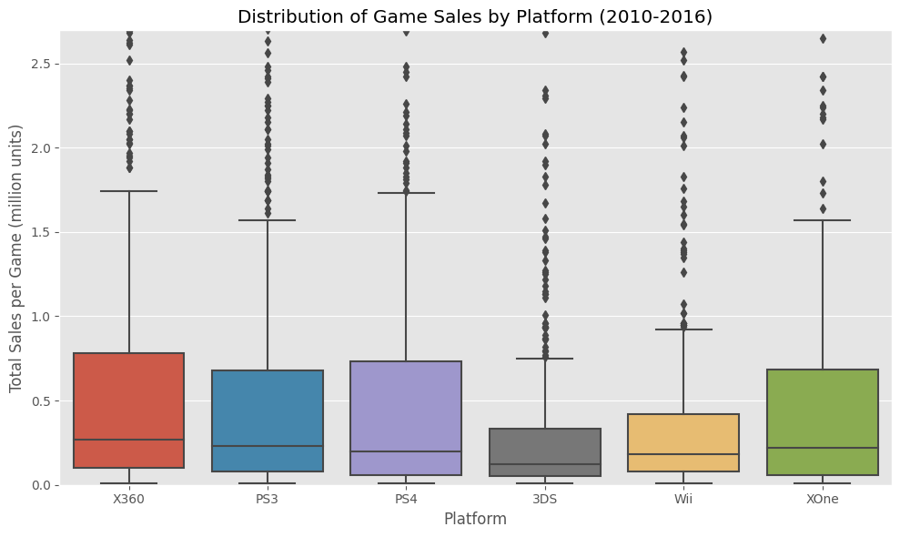

```python
# Create box plot of sales by top 6 platforms

top_platforms = (df_relevant.groupby('platform')['total_sales'].sum().sort_values(ascending=False)
    .head(6).index)

df_box = df_relevant[df_relevant['platform'].isin(top_platforms)]

plt.figure(figsize=(10, 6))
sns.boxplot(data=df_box, x='platform', y='total_sales')
plt.ylim(0, df_box['total_sales'].quantile(0.95)) # trim extreme outliers
plt.title('Distribution of Game Sales by Platform (2010-2016)')
plt.xlabel('Platform')
plt.ylabel('Total Sales per Game (million units)')
plt.tight_layout()
plt.show()
```

```python
# Calculate detailed statistics for each platform

platform_stats = (df_relevant.groupby('platform')['total_sales']
    .agg(['count', 'mean', 'median', 'std', 'min', 'max'])
    .sort_values('mean', ascending=False))
print("Sales statistics per platform in the selected period: (2010-2017)")
print(platform_stats.head(15))
print("\n")
print("Top 3 Platforms with highest median sales per game:\nX360, PS4, and PS3")
print("\nAmong the platforms with high variability indicating a mix of gaming hits and flops:\nX360, PS4, PS3, and 3DS")
```

[output not shown]

# Key Observations

Among the platforms with high variability indicating a mix of gaming hits and flops: X360, PS4, PS3, and 3DS

**Reviewer's comment v1**

Well done!

## 3.6 Review Score Impact Analysis

Select a popular platform and analyze how reviews affect sales:

```python
# Choose a popular platform based on your previous analysis
chosen_platform = 'PS4'
```

```python
# Create scatter plots for both critic and user scores

platform_df = df_relevant[df_relevant['platform'] == chosen_platform].copy()

print(f"Games on {chosen_platform} in selected period:",
      len(platform_df)),
platform_df[['name', 'year_of_release', 'total_sales', 'critic_score', 'user_score']].head()
```

```
Games on PS4 in selected period: 392
```

|  | name | year_of_release | total_sales | critic_score | user_score |
| --- | --- | --- | --- | --- | --- |
| 31 | Call of Duty: Black Ops 3 | 2015.00 | 14.63 | NaN | NaN |
| 42 | Grand Theft Auto V | 2014.00 | 12.62 | 97.00 | 8.30 |
| 77 | FIFA 16 | 2015.00 | 8.58 | 82.00 | 4.30 |
| 87 | Star Wars Battlefront (2015) | 2015.00 | 7.98 | NaN | NaN |
| 92 | Call of Duty: Advanced Warfare | 2014.00 | 7.66 | 83.00 | 5.70 |

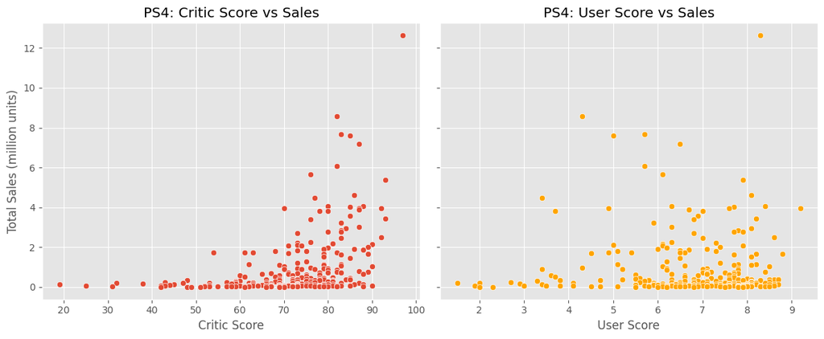

```
Correlation (sales vs critic_score) on PS4: 0.41
Correlation (sales vs user_score) on PS4: -0.03
```

```python
# Critic Scores
fig, axes = plt.subplots(1, 2, figsize=(12, 5), sharey=True)

sns.scatterplot(
    data=platform_df,
    x='critic_score',
    y='total_sales',
    ax=axes[0])

axes[0].set_title(f'{chosen_platform}: Critic Score vs Sales')
axes[0].set_xlabel('Critic Score')
axes[0].set_ylabel('Total Sales (million units)')

# User Scores
sns.scatterplot(
    data=platform_df,
    x='user_score',
    y='total_sales',
    ax=axes[1],
    color='orange')

axes[1].set_title(f'{chosen_platform}: User Score vs Sales')
axes[1].set_xlabel('User Score')

plt.tight_layout()
plt.show()

# Calculate correlations
corr_critic = platform_df[['total_sales',
                           'critic_score']].corr().iloc[0, 1]

corr_user = platform_df[['total_sales',
                         'user_score']].corr().iloc[0, 1]

print(f"Correlation (sales vs critic_score) on {chosen_platform}: {corr_critic:.2f}")
print(f"Correlation (sales vs user_score) on {chosen_platform}: {corr_user:.2f}")
```

**Reviewer's comment v1**

Well done!

## 3.7 Cross-Platform Comparison

Compare sales performance of games across different platforms:

```python
# Find games released on multiple platforms
name_platform_counts = (df.groupby('name')['platform']
    .nunique()
    .reset_index(name='platform_count'))
multi_platform_names = name_platform_counts[name_platform_counts['platform_count'] > 1]['name']

multi_df = df[df['name'].isin(multi_platform_names)].copy()

print("Number of multi-platform games:", multi_df['name'].nunique())
multi_df.head()
```

```
Number of multi-platform games: 2805
```

|  | name | platform | year_of_release | genre | na_sales | eu_sales | jp_sales | other_sales | critic_score | user_score | rating | total_sales |
| --- | --- | --- | --- | --- | --- | --- | --- | --- | --- | --- | --- | --- |
| 1 | Super Mario Bros. | NES | 1985.00 | Platform | 29.08 | 3.58 | 6.81 | 0.77 | NaN | NaN | NaN | 40.24 |
| 5 | Tetris | GB | 1989.00 | Puzzle | 23.20 | 2.26 | 4.22 | 0.58 | NaN | NaN | NaN | 30.26 |
| 16 | Grand Theft Auto V | PS3 | 2013.00 | Action | 7.02 | 9.09 | 0.98 | 3.96 | 97.00 | 8.20 | M | 21.05 |
| 17 | Grand Theft Auto: San Andreas | PS2 | 2004.00 | Action | 9.43 | 0.40 | 0.41 | 10.57 | 95.00 | 9.00 | M | 20.81 |
| 18 | Super Mario World | SNES | 1990.00 | Platform | 12.78 | 3.75 | 3.54 | 0.55 | NaN | NaN | NaN | 20.62 |

```
Sample of cross-platform sales:
                           name platform  total_sales
0          Frozen: Olaf's Quest      3DS         0.59
1          Frozen: Olaf's Quest       DS         0.51
2        007: Quantum of Solace       DS         0.13
3        007: Quantum of Solace       PC         0.02
4        007: Quantum of Solace      PS2         0.43
5        007: Quantum of Solace      PS3         1.15
6        007: Quantum of Solace      Wii         0.65
7        007: Quantum of Solace     X360         1.48
8  007: The World is not Enough      N64         1.56
9  007: The World is not Enough       PS         0.92
```

[figure not shown]

```
X360 platform tends to generate more sales for multi-platform games than PS3, PS4, and XOne alone
```

```python
# Compare sales across platforms for these games
multi_sales = (multi_df.groupby(['name', 'platform'])['total_sales']
    .sum()
    .reset_index())

print("Sample of cross-platform sales:")
print(multi_sales.head(10))

# Your code here to analyze and visualize cross-platform performance
focus_platforms = ['PS3', 'PS4', 'X360', 'XOne']
multi_focus = multi_sales[multi_sales['platform'].isin(focus_platforms)]

plt.figure(figsize=(10, 6))
sns.boxplot(data=multi_focus,
            x='platform',
            y='total_sales')
plt.title('Sales of Multi-Platform Games by Platform (2010-2016)')
plt.xlabel('Platform')
plt.ylabel('Total Sales per Game (million units)')
plt.tight_layout()
plt.show()

print("X360 platform tends to generate more sales for multi-platform games than PS3, PS4, and XOne alone")
```

# Key Observation:

## 3.8 Genre Analysis

Finally, let's examine the distribution of games by genre:

[output not shown]

[figure not shown]

```
Genres Action, Sports, and Shooter generate highest total sales among listed genres
Genres Platform, Shooter, and Role-playing achieve highest average per-game sales
Genres Platform and Shooter have high average sales with a lower number of games compared to Action
```

```python
# Analyze genre performance

genre_perf = (df.groupby('genre')['total_sales']
    .agg(['count', 'sum', 'mean', 'median'])
    .rename(columns={ 'count': 'num_games', 'sum': 'total_sales', 'mean': 'avg_sales', 'median': 'median_sales' })
    .sort_values('total_sales', ascending=False))

print("Genre performance in the selected period:")
print(genre_perf)

# Visualize total sales by genre
plt.figure(figsize=(10, 6))
sns.barplot(data=genre_perf.reset_index(),
            x='genre',
            y='total_sales',
            color='steelblue')
plt.title('Total Sales by Genre (2010-2016)')
plt.xlabel('Genre')
plt.ylabel('Total Sales (million units)')
plt.xticks(rotation=45, ha='right')
plt.tight_layout()
plt.show()

print("Genres Action, Sports, and Shooter generate highest total sales among listed genres")
print("Genres Platform, Shooter, and Role-playing achieve highest average per-game sales")
print("Genres Platform and Shooter have high average sales with a lower number of games compared to Action")
```

# Key Answers

Genres Action, Sports, and Shooter generate highest total sales among listed genres

Genres Platform, Shooter, and Role-playing achieve highest average per-game sales

Genres Platform and Shooter have high average sales with a lower number of games compared to Action

```python
# Calculate market share for each genre
total_market_sales = genre_perf['total_sales'].sum()
genre_perf['market_share_pct'] = (genre_perf['total_sales'] / total_market_sales * 100 )

print("Genre market share (% of total sales):")
print(genre_perf[['total_sales', 'market_share_pct']])
print("Genres Action, Sports, and Shooter hold the highest market share respectively")
```

```
Genre market share (% of total sales):
              total_sales  market_share_pct
genre
Action            1744.17             19.57
Sports            1331.27             14.94
Shooter           1052.45             11.81
Role-Playing       934.56             10.49
Platform           827.77              9.29
Misc               802.51              9.00
Racing             728.67              8.18
Fighting           447.53              5.02
Simulation         389.97              4.38
Puzzle             242.57              2.72
Adventure          237.59              2.67
Strategy           174.23              1.95
Genres Action, Sports, and Shooter hold the highest market share respectively
```

### Key Questions for Genre Analysis:

- Which genres consistently perform well?
- Are there any genres showing recent growth or decline?
- How does the average performance vary across genres?

# Step 4: Regional Market Analysis and User Profiles

In this section, we will analyze the gaming market characteristics across three major regions: North America (NA), Europe (EU), and Japan (JP). Our analysis will focus on platform preferences, genre popularity, and the impact of ESRB ratings in each region.

## 4.1 Regional Platform Analysis

Let's begin by examining platform performance across different regions:

```
Top 5 platforms in NA_SALES (2010-2016):
platform
X360   334.18
PS3    229.25
Wii    121.20
PS4    108.74
XOne    93.12
Name: na_sales, dtype: float64
```

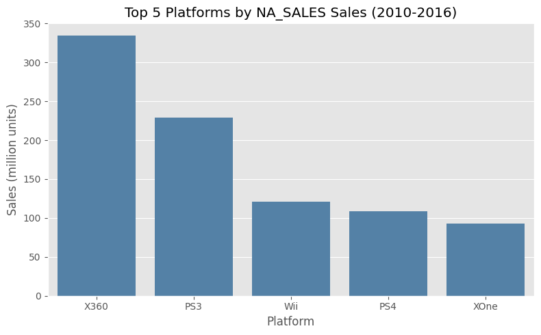

```
Top 5 platforms in EU_SALES (2010-2016):
platform
PS3    213.60
X360   163.41
PS4    141.09
PC      68.82
Wii     65.91
Name: eu_sales, dtype: float64
```

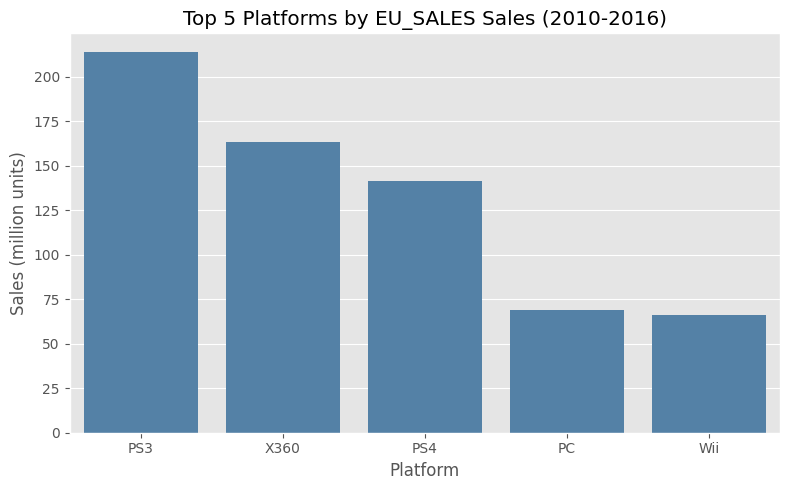

```
Top 5 platforms in JP_SALES (2010-2016):
platform
3DS   100.62
PS3    59.26
PSP    42.20
DS     27.90
PSV    21.84
Name: jp_sales, dtype: float64
```

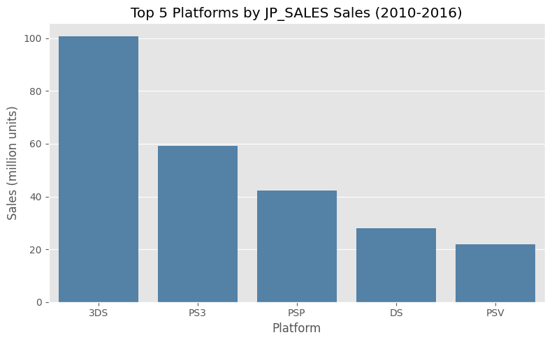

```
Top 5 platforms that dominate video game unit sales across NA, EU, and JP: X360, PS3, PS4, Wii, and 3DS
PS3 and X360 have strong video game unit sales in NA and EU but much less in JP
3DS has strong video game unit sales in JP but weaker sales presence in NA and EU
Wii has a modest video game unit sales presence in NA and EU while PC has modest sales in EU
```

```python
# Function to analyze platform performance by region

def analyze_platform_by_region(df, region_col, top_n=5):
    """ df : dataframe filtered to relevant years (df)
    region_col : one of ['na_sales', 'eu_sales', 'jp_sales', 'other_sales']
    top_n : how many top platforms to show
    """

# Aggregate sales by platform for the chosen region
    region_platform = (df.groupby('platform')[region_col]
    .sum()
    .sort_values(ascending=False))

    print(f"\nTop {top_n} platforms in {region_col.upper()} (2010-2016):")
    print(region_platform.head(top_n))

# Barplot of top platforms
    plt.figure(figsize=(8, 5))
    sns.barplot(x=region_platform.head(top_n).index,
                y=region_platform.head(top_n).values,
                color="steelblue")
    plt.title(f"Top {top_n} Platforms by {region_col.upper()} Sales (2010-2016)")
    plt.xlabel("Platform")
    plt.ylabel("Sales (million units)")
    plt.tight_layout()
    plt.show()

    return region_platform

# Example calls (run separately for each region)
na_platforms = analyze_platform_by_region(df_relevant, 'na_sales')
eu_platforms = analyze_platform_by_region(df_relevant, 'eu_sales')
jp_platforms = analyze_platform_by_region(df_relevant, 'jp_sales')

print("Top 5 platforms that dominate video game unit sales across NA, EU, and JP: X360, PS3, PS4, Wii, and 3DS")
print("PS3 and X360 have strong video game unit sales in NA and EU but much less in JP")
print("3DS has strong video game unit sales in JP but weaker sales presence in NA and EU")
print("Wii has a modest video game unit sales presence in NA and EU while PC has modest sales in EU")
```

# Key Observations

Top 5 platforms that dominate video game unit sales across NA, EU, and JP: X360, PS3, PS4, Wii, and 3DS

PS3 and X360 have strong video game unit sales in NA and EU but much less in JP

3DS has strong video game unit sales in JP but weaker sales presence in NA and EU

Wii has a modest video game unit sales presence in NA and EU while PC has modest sales in EU

```
1980.0 2016.0
Rows in original df: 16715

Top 5 platforms in OTHER_SALES (2010-2016):
platform
PS3    85.63
PS4    48.35
X360   47.36
Wii    18.11
XOne   14.27
Name: other_sales, dtype: float64
```

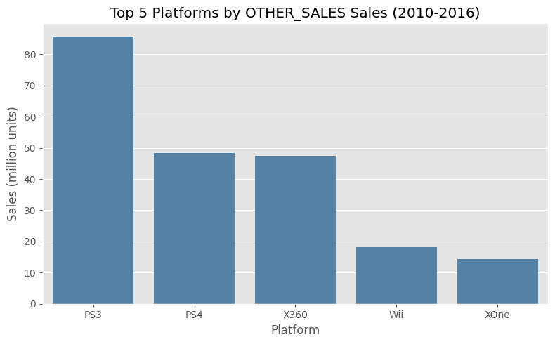

```
Platforms PS3, PS4, and X360 maintain strong video game unit sales accross multiple regions
```

```python
# Analyze each region
df_period = df[(df['year_of_release'] >= 2010) & (df['year_of_release'] <= 2016) ].copy()

print(df['year_of_release'].min(), df['year_of_release'].max())
print("Rows in original df:", len(df))


other_platforms = analyze_platform_by_region(df_relevant, 'other_sales', top_n=5)

print("Platforms PS3, PS4, and X360 maintain strong video game unit sales accross multiple regions")
```

# Key Observation

Platforms PS3, PS4, and X360 maintain strong video game unit sales accross multiple regions

### Cross-Regional Platform Comparison

Let's create a comparative analysis of platform performance across regions:

```python
# Create a comparative platform analysis

# 1) Aggregate regional sales by platform for the 2010-2016
regional_platform = (df_relevant.groupby('platform')[['na_sales', 'eu_sales', 'jp_sales', 'other_sales']]
    .sum())
# 2) Add total global sales and sort by it
regional_platform['global_sales'] = ( regional_platform[['na_sales', 'eu_sales', 'jp_sales', 'other_sales']]
    .sum(axis=1))
regional_platform = regional_platform.sort_values('global_sales', ascending=False)

print("Platform sales by region (top 10 by global sales):")
print(regional_platform.head(10))
```

```
Platform sales by region (top 10 by global sales):
          na_sales  eu_sales  jp_sales  other_sales  global_sales
platform
PS3         229.25    213.60     59.26        85.63        587.74
X360        334.18    163.41      5.46        47.36        550.41
PS4         108.74    141.09     15.96        48.35        314.14
3DS          82.65     61.27    100.62        13.27        257.81
Wii         121.20     65.91     17.75        18.11        222.97
XOne         93.12     51.59      0.34        14.27        159.32
DS           59.66     28.06     27.90         8.13        123.75
PC           39.07     68.82      0.00        14.07        121.96
WiiU         38.10     25.13     13.01         5.95         82.19
PSP           9.65      7.59     42.20         4.61         64.05
```

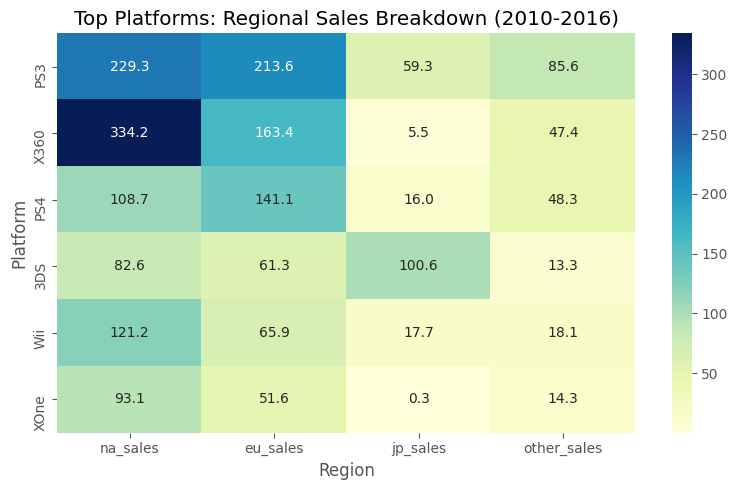

[output not shown]

```python
# Visualize cross-regional comparison for top platforms
top_platforms = regional_platform.head(6)

plt.figure(figsize=(8, 5))
sns.heatmap(top_platforms[['na_sales', 'eu_sales', 'jp_sales', 'other_sales']],
            annot=True,
            fmt=".1f",
            cmap="YlGnBu")

plt.title("Top Platforms: Regional Sales Breakdown (2010-2016)")
plt.xlabel("Region")
plt.ylabel("Platform")
plt.tight_layout()
plt.show()

print("Platforms XOne and Wii have a strong dependence for video game unit sales in NA and EU")
print("Platform 3DS has relatively strong video game unit sales in JP")
print("Platform PS3 has the greatest balance spread of video game unit sales across all regions")
print("Platforms X360 and PS4 have good balance spreads of video game unit sales across all regions")
```

# Key Observations

Platforms XOne and Wii have a strong dependence for video game unit sales in NA and EU

Platform 3DS has relatively strong video game unit sales in JP

Platform PS3 has the greatest balance spread of video game unit sales across all regions

## 4.2 Regional Genre Analysis

Now let's examine genre preferences across regions:

```
Top 5 genres in NA_SALES (selected period):
genre
Action         290.64
Shooter        237.47
Sports         156.81
Misc           123.80
Role-Playing   112.05
Name: na_sales, dtype: float64
```

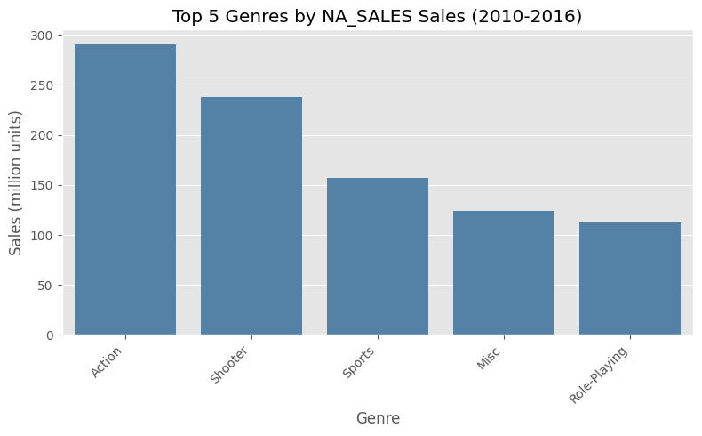

```
Top 5 genres in EU_SALES (selected period):
genre
Action         233.63
Shooter        171.45
Sports         116.84
Role-Playing    75.48
Misc            66.09
Name: eu_sales, dtype: float64
```

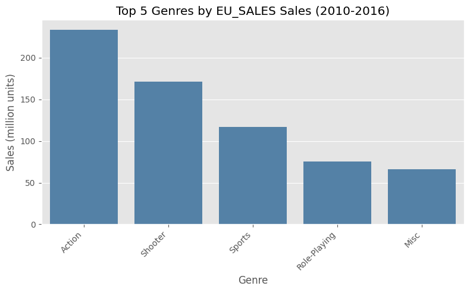

```
Top 5 genres in JP_SALES (selected period):
genre
Role-Playing   103.54
Action          72.20
Misc            24.29
Platform        15.81
Adventure       15.67
Name: jp_sales, dtype: float64
```

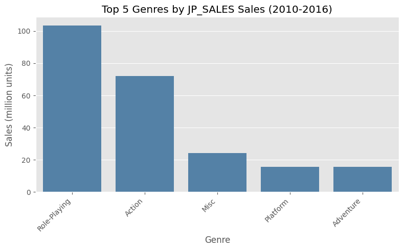

```
Top 5 genres in OTHER_SALES (selected period):
genre
Action         76.62
Shooter        56.78
Sports         39.23
Role-Playing   24.21
Misc           20.38
Name: other_sales, dtype: float64
```

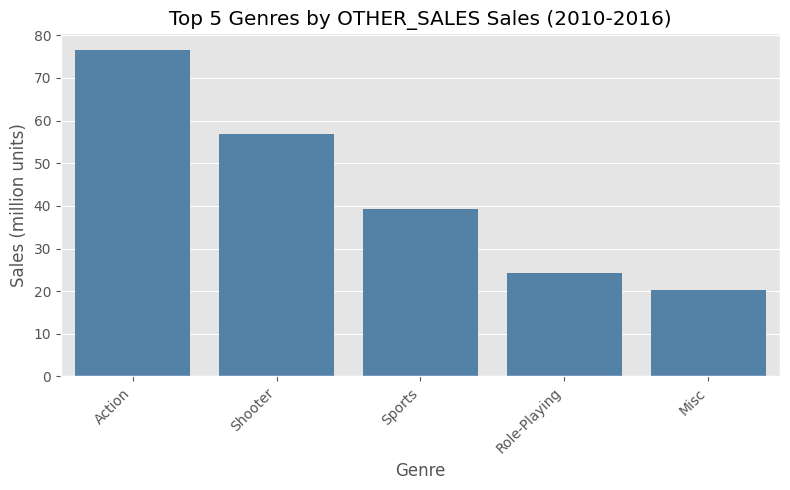

```
Genres Action, Shooter, and Sports have a predominant presence in video game sales in most regions
Genre Role-playing has a position in the top 5 of video game unit sales across all regions
```

```python
# Function to analyze genre performance by region
def analyze_genre_by_region(df, region_col, top_n=5):
    """
    df : dataframe filtered to relevant years (df)
    region_col : one of ['na_sales', 'eu_sales', 'jp_sales', 'other_sales']
    top_n : how many top genres to show
    """
    genre_region = (df.groupby('genre')[region_col].sum()
        .sort_values(ascending=False))

    print(f"\nTop {top_n} genres in {region_col.upper()} (selected period):")
    print(genre_region.head(top_n))

    plt.figure(figsize=(8, 5))
    sns.barplot( x=genre_region.head(top_n).index,
                 y=genre_region.head(top_n).values,
                 color="steelblue")
    plt.title(f"Top {top_n} Genres by {region_col.upper()} Sales (2010-2016)")
    plt.xlabel("Genre")
    plt.ylabel("Sales (million units)")
    plt.xticks(rotation=45, ha='right')
    plt.tight_layout()
    plt.show()

    return genre_region

    # Analayze each region
na_genres = analyze_genre_by_region(df_relevant, 'na_sales')
eu_genres = analyze_genre_by_region(df_relevant, 'eu_sales')
jp_genres = analyze_genre_by_region(df_relevant, 'jp_sales')
other_genres = analyze_genre_by_region(df_relevant, 'other_sales')

print("Genres Action, Shooter, and Sports have a predominant presence in video game sales in most regions")
print("Genre Role-playing has a position in the top 5 of video game unit sales across all regions")
```

# Key Observations

Genres Action, Shooter, and Sports have a predominant presence in video game sales in most regions

Genre Role-playing has a position in the top 5 of video game unit sales across all regions

### Cross-Regional Genre Comparison

Let's compare genre preferences across regions:

```
Genre sales by region (top 10 by global sales):
              na_sales  eu_sales  jp_sales  other_sales  global_sales
genre
Action          290.64    233.63     72.20        76.62        673.09
Shooter         237.47    171.45     14.04        56.78        479.74
Sports          156.81    116.84     15.51        39.23        328.39
Role-Playing    112.05     75.48    103.54        24.21        315.28
Misc            123.80     66.09     24.29        20.38        234.56
Racing           46.11     54.75      6.68        15.14        122.68
Platform         54.90     38.30     15.81        10.71        119.72
Fighting         39.05     20.33     13.90         8.31         81.59
Simulation       26.39     26.39     13.30         5.67         71.75
Adventure        20.84     18.88     15.67         5.61         61.00
```

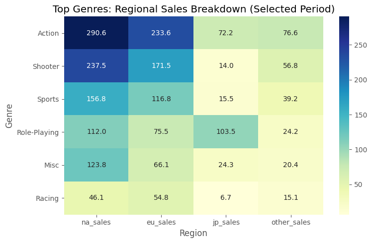

```
Genres Action, Shooter, and Sports have predominately high video game unit sales across most regions
Genre Role-Playing has fairly steady video game unit sales across all regions with an emphasis in JP sales
Genre Racing has a foothold in video game unit sales in NA and EU
```

```python
# Create a comparative genre analysis
# 1) Aggregate regional sales by genre
regional_genre = (df_relevant.groupby('genre')[['na_sales', 'eu_sales', 'jp_sales', 'other_sales']].sum())

# 2) Add global sales and sort
regional_genre['global_sales'] = (regional_genre[['na_sales', 'eu_sales', 'jp_sales', 'other_sales']].sum(axis=1))
regional_genre = regional_genre.sort_values('global_sales', ascending=False)

print("Genre sales by region (top 10 by global sales):")
print(regional_genre.head(10))

# Heatmap visualization for top genres by region
top_genres = regional_genre.head(6)
plt.figure(figsize=(8, 5))
sns.heatmap(top_genres[['na_sales', 'eu_sales', 'jp_sales', 'other_sales']],
            annot=True,
            fmt=".1f",
            cmap="YlGnBu")
plt.title("Top Genres: Regional Sales Breakdown (Selected Period)")
plt.xlabel("Region")
plt.ylabel("Genre")
plt.tight_layout()
plt.show()

print("Genres Action, Shooter, and Sports have predominately high video game unit sales across most regions")
print("Genre Role-Playing has fairly steady video game unit sales across all regions with an emphasis in JP sales")
print("Genre Racing has a foothold in video game unit sales in NA and EU")
```

# Key Observations

Genres Action, Shooter, and Sports have predominately high video game unit sales across most regions

Genre Role-Playing has fairly steady video game unit sales across all regions with an emphasis in JP sales

Genre Racing has a foothold in video game unit sales in NA and EU

## 4.3 ESRB Rating Impact Analysis

Finally, let's examine how ESRB ratings affect sales in each region:

```
Sales by ESRB rating and region:
        na_sales  eu_sales  jp_sales  other_sales  global_sales
rating
E        1292.99    710.25    198.11       234.17       2435.52
T         759.75    427.03    151.40       155.17       1493.35
M         748.48    483.97     64.24       177.10       1473.79
E10+      353.32    188.52     40.20        73.56        655.60
K-A         2.56      0.27      1.46         0.03          4.32
AO          1.26      0.61      0.00         0.09          1.96
EC          1.53      0.11      0.00         0.11          1.75
RP          0.00      0.08      0.00         0.01          0.09
```

[figure not shown]

[output not shown]

```python
# Function to analyze ESRB rating impact
def analyze_esrb_by_region(df, top_n=None):
    """
    df : dataframe filtered to relevant years (df_relevant),
    must have 'rating' and regional sales columns.
    """
    rating_region = (df.groupby('rating')[['na_sales', 'eu_sales', 'jp_sales', 'other_sales']]
        .sum())
    rating_region['global_sales'] = (rating_region[['na_sales', 'eu_sales', 'jp_sales', 'other_sales']]
        .sum(axis=1))
    rating_region = rating_region.sort_values('global_sales', ascending=False)

    if top_n is not None:
        rating_region = rating_region.head(top_n)

    print("Sales by ESRB rating and region:")
    print(rating_region)

# Heatmap visualization
    plt.figure(figsize=(7, 4))
    sns.heatmap(rating_region[['na_sales', 'eu_sales', 'jp_sales', 'other_sales']],
                annot=True,
                fmt=".1f",
                cmap="OrRd")

    plt.title("ESRB Rating: Regional Sales Breakdown (2010-2016)")
    plt.xlabel("Region")
    plt.ylabel("ESRB Rating")
    plt.tight_layout()
    plt.show()

    return rating_region

# Call on your filtered data
rating_region = analyze_esrb_by_region(df)

print("ESRB Ratings E, T, and M generate highest video game unit sales across all regions")
print("ESRB Rating E has strongest overall video game unit sales across all regions")
print("ESRB Ratings T and M also have strong overall video game unit sales")
print("ESRB Ratings T and M could potentially have greater video game unit sales than ESRB Rating E video games sold in some marginal regions (Other regions)")
```

# Key Observations

ESRB Ratings E, T, and M generate highest video game unit sales across all regions

ESRB Rating E has strongest overall video game unit sales across all regions

ESRB Ratings T and M also have strong overall video game unit sales

```python
# Analyze ESRB impact for each region
def esrb_region_summary(df, region_col):
    summary = (df.groupby('rating')[region_col]
        .agg(['count', 'sum', 'mean'])
        .rename(columns={'count': 'num_games', 'sum': 'total_sales', 'mean': 'avg_sales'})
        .sort_values('total_sales', ascending=False))

    print(f"\nESRB impact in {region_col.upper()} (selected period):")
    print(summary)

    return summary

na_esrb = esrb_region_summary(df, 'na_sales')
eu_esrb = esrb_region_summary(df, 'eu_sales')
jp_esrb = esrb_region_summary(df, 'jp_sales')
oth_esrb = esrb_region_summary(df, 'other_sales')

print("ESRB Ratings E, T, and M dominate total sales and average sales across most regions")
print("ESRB Rating E10+ generates significantly less in sales across most regions considering the number of E10+ games created ")
print("ESRB Rating M has less pronounced total sales in JP than in NA and EU")
```

[output not shown]

# Key Observations

ESRB Ratings E, T, and M dominate total sales and average sales across most regions

ESRB Rating M has less pronounced total sales in JP than in NA and EU

**Reviewer's comment v1**

Each analysis of each section was very well done; the answers to the questions you gave are very valuable and give us a better understanding of the data.

# Step 5 : Hypothesis Tests

—Average user ratings of the Xbox One and PC platforms are the same.

—Average user ratings for the Action and Sports genres are different.

Set the *alpha* threshold value yourself.

Explain:

—How you formulated the null and alternative hypotheses

—What criteria you used to test the hypotheses, and why

```python
# statistical significance threshold
alpha = 0.05

# Work on rows that have a user_score
ratings = df.dropna(subset=['user_score'])

# Xbox One vs PC
# Null hypothesis: average user ratings on XOne and PC are equal
xone_scores = ratings.loc[ratings['platform'] == 'XOne', 'user_score']

# Alternative hypothesis: average user ratings are not equal
pc_scores = ratings.loc[ratings['platform'] == 'PC', 'user_score']

# Welch's t‑test: platform samples are independent with different variances and sizes
t_stat_1, p_val_1 = stats.ttest_ind( xone_scores, pc_scores, equal_var=False)

print("Xbox One vs PC:")
print("mean XOne:", xone_scores.mean())
print("mean PC :", pc_scores.mean())
print("t-statistic:", t_stat_1, "p-value:", p_val_1)

if p_val_1 < alpha:
    print("Reject H0: average user ratings differ.")
else:
    print("Fail to reject H0: no significant difference in averages.")


# Action vs Sports
# Null hypothesis: user ratings for Action and Sports are equal
action_scores = ratings.loc[ratings['genre'] == 'Action', 'user_score']

# Null hypothesis: user ratings for Action and Sports are not equal
sports_scores = ratings.loc[ratings['genre'] == 'Sports', 'user_score']

# Welch's t-test: platform samples are independent with different variances and sizes
t_stat_2, p_val_2 = stats.ttest_ind( action_scores, sports_scores, equal_var=False)

print("\nAction vs Sports:")
print("mean Action:", action_scores.mean())
print("mean Sports:", sports_scores.mean())
print("t-statistic:", t_stat_2, "p-value:", p_val_2)

if p_val_2 < alpha:
    print("Reject H0: average user ratings differ.")
else:
    print("Fail to reject H0: no significant difference in averages.")
```

```
Xbox One vs PC:
mean XOne: 6.521428571428572
mean PC : 7.062467532467533
t-statistic: -4.653422798410771 p-value: 4.935072360183574e-06
Reject H0: average user ratings differ.

Action vs Sports:
mean Action: 7.054043715846995
mean Sports: 6.961196736174069
t-statistic: 1.57746791633354 p-value: 0.11483818791498286
Fail to reject H0: no significant difference in averages.
```

**Reviewer's comment v1**

Don't forget to add conclusions.

# Step 6. Write a general conclusion

Across 2010-2016, few leading platforms, such as PlaysStation and Xbox consoles, consistently generated the highest total and regional sales, especially in North America and Europe.\n regional analysis reveals taht Japan favored a narrower band of platforms and genres, often differing from Western regions.\n Marginal regions (Other regions) meanwhile had smaller but more balanced platform shares. Genre analysis indicated that blochbuster genres, such as Action and Shooter, dominated total sales, but some mid-tier genres achieved stronger sales per title, suggesting profitable niches despite fewer releases. Regional genre preferences also diverge: Western regions leaned most into Action and Shooter genres whereas Japan demonstrated relatively greater interest in Role-playing and niche games.

ESRB rating analysis suggested that broad-appealing ratings like E, E10+, and T contributed substantially to the share of total sales. M rated titles remained particularly important in sales throughout North America and Europe while large portions of the dataset lacked rating and review information. Therefore, rating-based conclusions should be interpreted more cautiously when making predictions about future 2017 rating and sales.

All together, the results suggest that successful marketing and forecasting for 2017 should focus on the dominant platforms and genres in each target region, prioritze titles with ratings appropriate for the intended audience, and account for genre-specific differences in user reception rather than to assume all popular genres are perceived equally.

**Reviewer's comment v1**

So, should we only invest in AAA games? Would that be correct, especially now that it's 2025? Has that been the history of video games?

# Data Description

Dataset: /datasets/games.csv (https://tripleten.com/trainer/aiml/lesson/2fede7ea-9ca6-42a3-ba35-bf4142d2fcc0/task/f06a283c-8d3c-49e0-b6cd-d7b06e69afa0/#:~:text=games.csv%20.-,Download%20dataset,-Step%202.%20Prepare)

Dataset Columns:

Name: video game title

Platform: console under which video games are played

Year_of_Release: year the platform's video game was released

Genre: Style of the video game

NA_sales: North American sales in USD million

EU_sales: Europe sales in USD million

JP_sales: Japan sales in USD million

Other_sales: Sales in other countries besides NA, EU, and JP (In USD million)

Critic_Score: Max of 100 (partially incomplete)

User_Score: Max of 10 (partially incomplete)

Rating (ESRB): Quality or perceived satisfaction of the user (partially incomplete)